# Diabetes Comparison

Yuqing Cai

2024-04-10

## Introduction

For this assignment, a data file “diabetes.csv” with 768 observations was given. The tasks include setting seeds, using bootstrap, finding the mean, standard deviation and percentile for various variables, as well as creating visual comparisons. The first step is to read the csv file:

```r
raw_data <- read.csv("C:/Users/yuqin/Desktop/CS5530/CS5530Assignment3and4/Cai - DiabetesProject/data_raw/diabetes.csv")
glimpse(raw_data)
```

```
## Rows: 768
## Columns: 9
## $ Pregnancies              <int> 6, 1, 8, 1, 0, 5, 3, 10, 2, 8, 4, 10, 10, 1, …
## $ Glucose                  <int> 148, 85, 183, 89, 137, 116, 78, 115, 197, 125…
## $ BloodPressure            <int> 72, 66, 64, 66, 40, 74, 50, 0, 70, 96, 92, 74…
## $ SkinThickness            <int> 35, 29, 0, 23, 35, 0, 32, 0, 45, 0, 0, 0, 0, …
## $ Insulin                  <int> 0, 0, 0, 94, 168, 0, 88, 0, 543, 0, 0, 0, 0, …
## $ BMI                      <dbl> 33.6, 26.6, 23.3, 28.1, 43.1, 25.6, 31.0, 35.…
## $ DiabetesPedigreeFunction <dbl> 0.627, 0.351, 0.672, 0.167, 2.288, 0.201, 0.2…
## $ Age                      <int> 50, 31, 32, 21, 33, 30, 26, 29, 53, 54, 30, 3…
## $ Outcome                  <int> 1, 0, 1, 0, 1, 0, 1, 0, 1, 1, 0, 1, 0, 1, 1, …
```

## Set seed

Next, we will set a seed to ensure work reproducibility, and take a random sample of 25 observations, find the mean Glucose and highest Glucose values of this sample and compare these statistics with the population statistics of the same variable:

```r
set.seed(123)

sample_data <- raw_data %>%
  sample_n(25)

sample_mean <- mean(sample_data$Glucose)
sample_max <- max(sample_data$Glucose)

population_mean <- mean(raw_data$Glucose)
population_max <- max(raw_data$Glucose)

glucose_comparison <- data.frame (
  Statistic = c("mean Glucose", "highest Glucose"),
  Sample = c(sample_mean, sample_max),
  Population = c(population_mean, population_max)
)
```

Here is the chart for comparison:

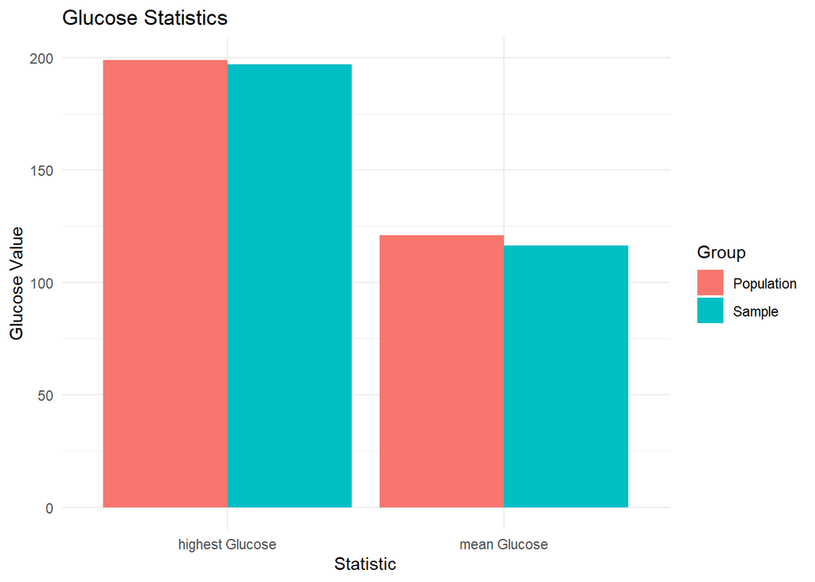

## BMI

The next step is to find the 98th percentile of BMI of your sample and the population and compare the results using charts:

```r
sample_bmi98 <- quantile(sample_data$BMI, probs = 0.98)
population_bmi98 <- quantile(raw_data$BMI, probs = 0.98)


bmi_comparison <- data.frame(
  Group = c("Sample", "Population"),
  bmi98 = c(sample_bmi98, population_bmi98)
)
```

Here is the comparison of 98th percentile of BMI between population and sample:

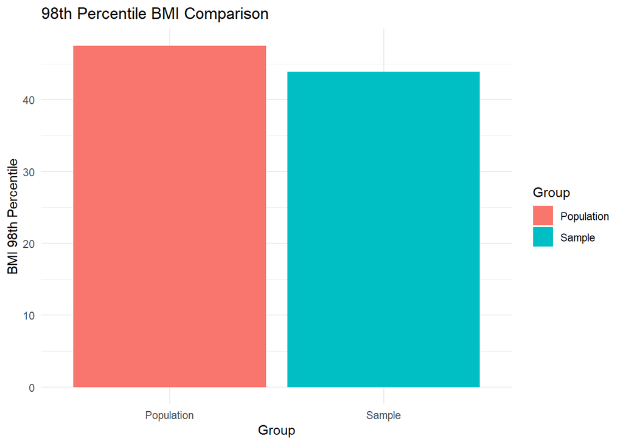

The last task to complete is to use bootstrap (replace= True), create 500 samples (of 150 observation each) from the population and find the average mean, standard deviation and percentile for Blood Pressure, and compare this with these statistics from the population for the same variable:

```r
bp_stat <- function(data) {
  mean_bp <- mean(data$BloodPressure)
  sd_bp <- sd(data$BloodPressure)
  percentile_95th_bp <- quantile(data$BloodPressure, probs = 0.95)
  return(c(mean_bp, sd_bp, percentile_95th_bp))
}

set.seed(123)

bootstrap_samples <- replicate(500, {
  sample_data <- raw_data %>%
    sample_n(150, replace = TRUE)
  bp_stat(sample_data)
}, simplify = FALSE)

bootstrap_df <- as.data.frame(do.call(rbind, bootstrap_samples))

colnames(bootstrap_df) <- c("Mean", "StandardDeviation", "95thPercentile")

population_statistics <- bp_stat(raw_data)

comparison_data <- data.frame(
  Statistic = c("Mean", "Standard Deviation", "95th Percentile"),
  Sample = colMeans(bootstrap_df),
  Population = population_statistics
)
```

Now, we can see the comparison of mean, standard deviation and percentile for Blood Pressure:

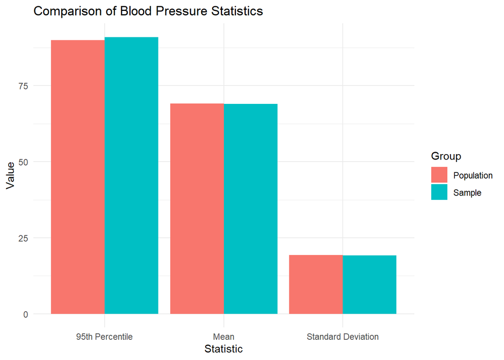